# Characterisation of OMOP CDM

# 2 Introduction

In this vignette, we explore how *OmopSketch* functions can serve as a valuable tool for characterising databases containing electronic health records mapped to the OMOP Common Data Model.

## 2.1 Create a mock cdm

Let’s see an example of its functionalities. To start with, we will load essential packages and connect to a test CDM using the Eunomia dataset.

```r
library(dplyr)
library(DBI)
library(duckdb)
library(OmopSketch)


# Connect to Eunomia database
con <- DBI::dbConnect(duckdb::duckdb(), CDMConnector::eunomiaDir())
cdm <- CDMConnector::cdmFromCon(
  con = con, cdmSchema = "main", writeSchema = "main", cdmName = "Eunomia"
)

cdm
```

```
#>
#> ── # OMOP CDM reference (duckdb) of Eunomia ────────────────────────────────────
#> • omop tables: person, observation_period, visit_occurrence, visit_detail,
#> condition_occurrence, drug_exposure, procedure_occurrence, device_exposure,
#> measurement, observation, death, note, note_nlp, specimen, fact_relationship,
#> location, care_site, provider, payer_plan_period, cost, drug_era, dose_era,
#> condition_era, metadata, cdm_source, concept, vocabulary, domain,
#> concept_class, concept_relationship, relationship, concept_synonym,
#> concept_ancestor, source_to_concept_map, drug_strength
#> • cohort tables: -
#> • achilles tables: -
#> • other tables: -
```

# 3 Snapshot

Let’s start by using the `summariseOmopSnapshot()` function to summarise the available metadata of the cdm_reference object, including the vocabulary version and the time span covered by the `observation_period` table

```r
snapshot <- summariseOmopSnapshot(cdm)
snapshot |>
  tableOmopSnapshot()
```

| Estimate | Database name Eunomia |
| --- | --- |
| General |  |
| Snapshot date | 2025-06-18 |
| Person count | 2,694 |
| Vocabulary version | v5.0 18-JAN-19 |
| Observation period |  |
| N | 5,343 |
| Start date | 1908-09-22 |
| End date | 2019-07-03 |
| Cdm |  |
| Source name | Synthea synthetic health database |
| Version | v5.3.1 |
| Holder name | OHDSI Community |
| Release date | 2019-05-25 |
| Description | SyntheaTM is a Synthetic Patient Population Simulator. The goal is to output synthetic, realistic (but not real), patient data and associated health records in a variety of formats. |
| Documentation reference | https://synthetichealth.github.io/synthea/ |
| Source type | duckdb |

# 4 Clinical tables characterisation

Next, we define the tables of interest, specify the study period, and determine whether to stratify the analysis by sex, age groups, or time intervals.

```r
tableName <- c(
  "observation_period", "visit_occurrence", "condition_occurrence", "drug_exposure", "procedure_occurrence",
  "device_exposure", "measurement", "observation", "death"
)

dateRange <- as.Date(c("2012-01-01", NA))

sex <- TRUE

ageGroup <- list(c(0, 59), c(60, Inf))

interval <- "years"
```

## 4.1 Missing values

We can now use the `summariseMissingData()` function to assess the presence of missing values in the tables.

```r
result_missingData <- summariseMissingData(cdm,
  omopTableName = tableName,
  sex = sex,
  ageGroup = ageGroup,
  interval = interval,
  dateRange = dateRange
)
result_missingData |> glimpse()
```

```
#> Rows: 26,726
#> Columns: 13
#> $ result_id        <int> 1, 1, 1, 1, 1, 1, 1, 1, 1, 1, 1, 1, 1, 1, 1, 1, 1, 1,…
#> $ cdm_name         <chr> "Eunomia", "Eunomia", "Eunomia", "Eunomia", "Eunomia"…
#> $ group_name       <chr> "omop_table", "omop_table", "omop_table", "omop_table…
#> $ group_level      <chr> "observation_period", "observation_period", "observat…
#> $ strata_name      <chr> "overall", "overall", "overall", "overall", "overall"…
#> $ strata_level     <chr> "overall", "overall", "overall", "overall", "overall"…
#> $ variable_name    <chr> "observation_period_id", "observation_period_id", "ob…
#> $ variable_level   <chr> NA, NA, NA, NA, NA, NA, NA, NA, NA, NA, NA, NA, NA, N…
#> $ estimate_name    <chr> "na_count", "na_percentage", "zero_count", "zero_perc…
#> $ estimate_type    <chr> "integer", "percentage", "integer", "percentage", "in…
#> $ estimate_value   <chr> "0", "NaN", "0", "NaN", "0", "NaN", "0", "NaN", "0", …
#> $ additional_name  <chr> "overall", "overall", "overall", "overall", "overall"…
#> $ additional_level <chr> "overall", "overall", "overall", "overall", "overall"…
```

## 4.2 Clinical tables overview

The function `sumamriseClinicalRecords()` provides key insights into the clinical tables content, including the number of records, number of subjects, portion of records in observation, and the number of distinct domains and concepts.

```r
result_clinicalRecords <- summariseClinicalRecords(cdm,
  omopTableName = tableName,
  sex = sex,
  ageGroup = ageGroup,
  dateRange = dateRange
)
```

[output not shown]

```r
result_clinicalRecords |> tableClinicalRecords()
```

| Variable name | Variable level | Estimate name | Database name Eunomia |
| --- | --- | --- | --- |
| observation_period; overall; overall |  |  |  |
| Number records | - | N | 0.00 |
| Number subjects | - | N (%) | 0 (0.00%) |
| Records per person | - | Mean (SD) | 0.00 (0.00) |
|  |  | Median [Q25 - Q75] | 0.00 [0.00 - 0.00] |
|  |  | Range [min to max] | [0.00 to 0.00] |
| observation_period; 0 to 59; overall |  |  |  |
| Number records | - | N | 0.00 |
| Number subjects | - | N (%) | 0 (0.00%) |
| Records per person | - | Mean (SD) | 0.00 (0.00) |
|  |  | Median [Q25 - Q75] | 0.00 [0.00 - 0.00] |
|  |  | Range [min to max] | [0.00 to 0.00] |
| observation_period; 60 or above; overall |  |  |  |
| Number records | - | N | 0.00 |
| Number subjects | - | N (%) | 0 (0.00%) |
| Records per person | - | Mean (SD) | 0.00 (0.00) |
|  |  | Median [Q25 - Q75] | 0.00 [0.00 - 0.00] |
|  |  | Range [min to max] | [0.00 to 0.00] |
| observation_period; overall; Female |  |  |  |
| Number records | - | N | 0.00 |
| Number subjects | - | N (%) | 0 (0.00%) |
| Records per person | - | Mean (SD) | 0.00 (0.00) |
|  |  | Median [Q25 - Q75] | 0.00 [0.00 - 0.00] |
|  |  | Range [min to max] | [0.00 to 0.00] |
| observation_period; overall; Male |  |  |  |
| Number records | - | N | 0.00 |
| Number subjects | - | N (%) | 0 (0.00%) |
| Records per person | - | Mean (SD) | 0.00 (0.00) |
|  |  | Median [Q25 - Q75] | 0.00 [0.00 - 0.00] |
|  |  | Range [min to max] | [0.00 to 0.00] |

[output cut: 700 more lines]

## 4.3 Records in observation

We can retrieve the number of records in observation for each table using the `summariseRecordCount()` function.

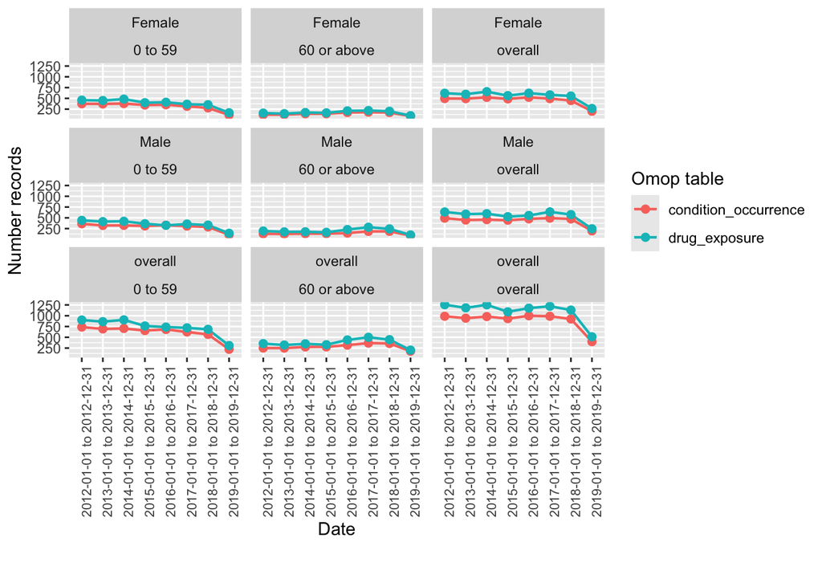

```r
result_recordCounts <- summariseRecordCount(cdm,
  tableName,
  sex = sex,
  ageGroup = ageGroup,
  interval = interval,
  dateRange = dateRange
)
result_recordCounts |>
  filter(group_level %in% c("drug_exposure", "condition_occurrence")) |>
  plotRecordCount(
    colour = "omop_table",
    facet = c("sex", "age_group")
  )
```

## 4.4 Concept id counts

We can then use the `summariseConceptIdCounts()` function to compute the record counts for each concept_id present in the analysed OMOP tables.

```r
result_conceptIdCount <- OmopSketch::summariseConceptIdCounts(cdm,
  omopTableName = tableName,
  sex = sex,
  ageGroup = ageGroup,
  interval = interval,
  dateRange = dateRange
)
result_conceptIdCount |> glimpse()
```

```
#> Rows: 10,614
#> Columns: 13
#> $ result_id        <int> 1, 1, 1, 1, 1, 1, 1, 1, 1, 1, 1, 1, 1, 1, 1, 1, 1, 1,…
#> $ cdm_name         <chr> "Eunomia", "Eunomia", "Eunomia", "Eunomia", "Eunomia"…
#> $ group_name       <chr> "omop_table", "omop_table", "omop_table", "omop_table…
#> $ group_level      <chr> "visit_occurrence", "visit_occurrence", "visit_occurr…
#> $ strata_name      <chr> "overall", "age_group", "age_group", "sex", "sex", "o…
#> $ strata_level     <chr> "overall", "60 or above", "0 to 59", "Female", "Male"…
#> $ variable_name    <chr> "Inpatient Visit", "Inpatient Visit", "Inpatient Visi…
#> $ variable_level   <chr> "9201", "9201", "9201", "9201", "9201", "9201", "9201…
#> $ estimate_name    <chr> "count_records", "count_records", "count_records", "c…
#> $ estimate_type    <chr> "integer", "integer", "integer", "integer", "integer"…
#> $ estimate_value   <chr> "163", "32", "131", "85", "78", "20", "30", "17", "9"…
#> $ additional_name  <chr> "source_concept_id &&& source_concept_name", "source_…
#> $ additional_level <chr> "0 &&& No matching concept", "0 &&& No matching conce…
```

# 5 Observation period characterisation

`OmopSketch` can also provide an overview of the `observation_period` table.

## 5.1 Subjects in observation

The `summariseInObservation()` function calculates the number of subjects and the distribution of person-days in observation across specific time intervals.

```
#> `result_id` is not present in result.
#> `result_id` is not present in result.
```

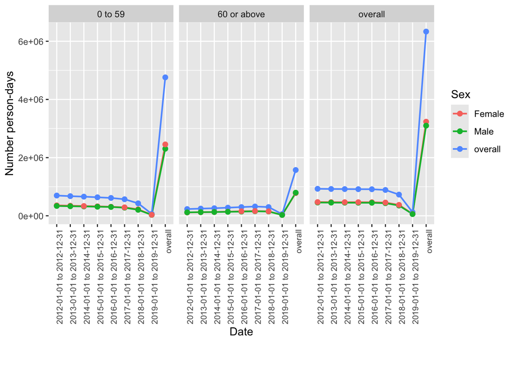

```r
result_inObservation <-summariseInObservation(cdm$observation_period,
                                              output = c("record","person-days"),
                                              interval = interval,
                                              sex = sex,
                                              ageGroup = ageGroup,
                                              dateRange = dateRange)

result_inObservation |>
  filter(variable_name == "Number person-days") |>
  plotInObservation(colour = "sex",
                    facet = "age_group")
```

```
#> `result_id` is not present in result.
#> `result_id` is not present in result.
```

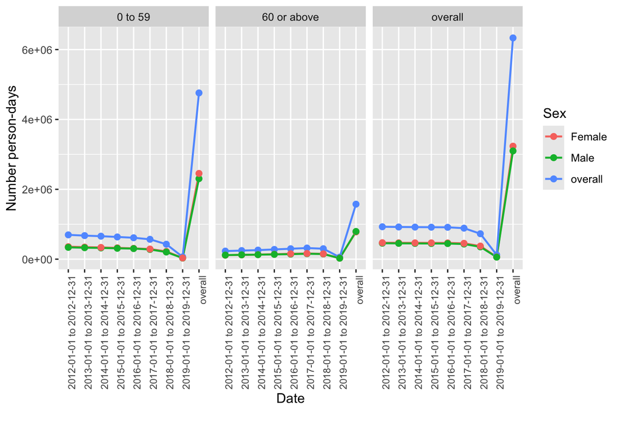

```r
result_inObservation |>
  filter(variable_name == "Number person-days") |>
  plotInObservation(
    colour = "sex",
    facet = "age_group"
  )
```

## 5.2 Observation periods

From the `observation_table`, we can extract information on the duration of observation periods, the time until the next observation period, and the number of subjects in each ordinal observation period (1st, 2nd, etc.). This can be done using the `summariseObservationPeriod()` function.

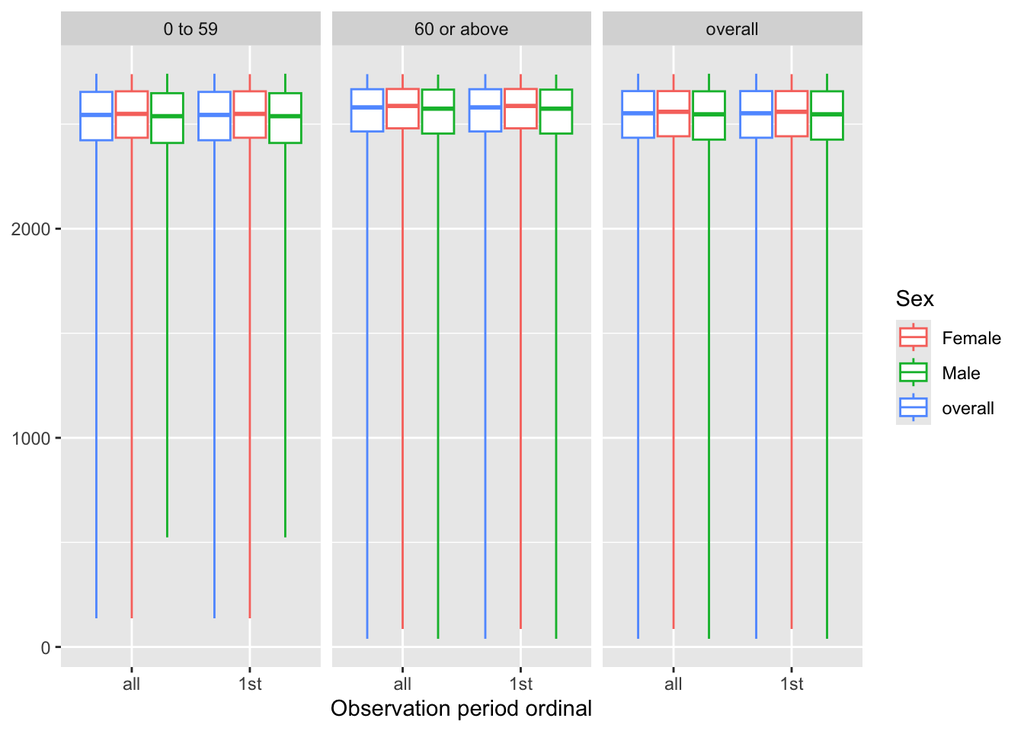

```r
result_observationPeriod <- summariseObservationPeriod(cdm$observation_period,
  sex = sex,
  ageGroup = ageGroup,
  dateRange = dateRange
)

result_observationPeriod |>
  plotObservationPeriod(
    variableName = "Duration in days",
    plotType = "boxplot",
    colour = "sex",
    facet = "age_group"
  )
```

Finally, disconnect from the cdm

```r
PatientProfiles::mockDisconnect(cdm = cdm)
```

The results of the characterisation using `OmopSketch` can be further explored through the ShinyApp at https://dpa-pde-oxford.shinyapps.io/OmopSketch-vignette/